# Expansión de la CASEN sobre el CENSO a nivel de manzana (PASO 2)

VE-CC-AJ

DataIntelligence

date: 22-07-2021

# 1 Leemos el archivo censo2017_manzanas.csv

```r
manzanas <- read.csv('../../../archivos_grandes/censo2017_manzanas.csv',sep=";")
```

```r
nrow(manzanas)
```

```
## [1] 180499
```

```r
abc <- head(manzanas,15)
kbl(abc) %>%
  kable_styling(bootstrap_options = c("striped", "hover")) %>%
  kable_paper() %>%
  scroll_box(width = "100%", height = "300px")
```

REGION

PROVINCIA

COMUNA

DC

AREA

ZC_LOC

MZ_ENT

ID_ZONA_LOC

ID_MANZENT

PERSONAS

HOMBRES

MUJERES

EDAD_0A5

EDAD_6A14

EDAD_15A64

EDAD_65YMAS

INMIGRANTES

PUEBLO

VIV_PART

VIV_COL

VPOMP

TOTAL_VIV

CANT_HOG

P01_1

P01_2

P01_3

P01_4

P01_5

P01_6

P01_7

P03A_1

P03A_2

P03A_3

P03A_4

P03A_5

P03A_6

P03B_1

P03B_2

P03B_3

P03B_4

P03B_5

P03B_6

P03B_7

P03C_1

P03C_2

P03C_3

P03C_4

P03C_5

MATACEP

MATREC

MATIRREC

P05_1

P05_2

P05_3

P05_4

REGION_15R

PROVINCIA_15R

COMUNA_15R

ID_MANZENT_15R

1

11

1101

1

1

1

1

7849

1.10101e+12

15

0

0

15

0

0

0

1

2

0

3

0

0

0

0

0

0

0

1

0

0

0

0

0

0

0

0

0

0

0

0

0

0

0

0

0

0

0

0

0

0

0

0

0

1

11

1101

1.10101e+12

1

11

1101

1

1

1

10

7849

1.10101e+12

70

38

32

54

10

12

13

17

1

15

18

24

16

0

0

1

0

0

0

0

1

13

1

0

0

8

0

7

0

0

0

0

15

0

0

0

0

14

1

0

15

0

0

0

1

11

1101

1.10101e+12

1

11

1101

1

1

1

11

7849

1.10101e+12

36

21

15

0

28

11

7

15

1

15

16

15

2

0

0

13

0

0

0

0

0

15

0

0

0

0

0

15

0

0

0

0

10

0

0

5

0

10

5

0

15

0

0

0

1

11

1101

1.10101e+12

1

11

1101

1

1

1

12

7849

1.10101e+12

65

34

31

7

49

27

4

24

0

24

24

28

24

0

0

0

0

0

0

2

4

11

7

0

0

5

2

13

0

0

3

1

18

1

4

1

0

11

9

4

24

0

0

0

1

11

1101

1.10101e+12

1

11

1101

1

1

1

13

7849

1.10101e+12

39

12

27

26

7

4

17

11

2

9

13

9

9

1

0

0

1

0

0

0

4

5

0

0

0

6

0

3

0

0

0

0

9

0

0

0

0

9

0

0

9

0

0

0

1

11

1101

1.10101e+12

1

11

1101

1

1

1

14

7849

1.10101e+12

160

69

91

18

17

116

9

62

19

75

0

62

75

64

29

17

0

29

0

0

0

22

13

25

2

0

0

30

0

32

0

0

0

0

59

0

2

1

0

57

5

0

61

0

0

0

1

11

1101

1.10101e+12

1

11

1101

1

1

1

15

7849

1.10101e+12

19

14

8

0

7

8

7

8

0

0

0

0

0

0

4

2

1

0

0

0

0

1

6

0

0

0

0

5

0

2

0

0

5

2

0

7

0

0

0

1

11

1101

1.10101e+12

1

11

1101

1

1

1

16

7849

1.10101e+12

456

223

233

39

47

334

36

40

77

213

0

163

213

170

44

168

0

1

0

0

0

107

31

21

3

0

0

30

114

16

1

0

1

0

160

1

1

0

0

157

4

1

163

0

0

0

1

11

1101

1.10101e+12

1

11

1101

1

1

1

17

7849

1.10101e+12

203

111

92

18

26

144

15

53

49

100

1

80

101

80

44

0

0

56

0

0

0

14

4

42

17

2

0

46

2

28

3

0

0

0

60

0

6

12

0

42

35

0

80

0

0

0

1

11

1101

1.10101e+12

1

11

1101

1

1

1

18

7849

1.10101e+12

132

68

64

8

17

93

14

30

23

72

0

43

72

45

42

0

0

30

0

0

0

6

11

16

9

0

0

32

0

11

0

0

0

0

38

0

5

0

0

28

14

0

43

0

0

0

1

11

1101

1.10101e+12

1

11

1101

1

1

1

19

7849

1.10101e+12

34

14

20

0

4

18

12

16

0

14

16

14

14

1

0

0

0

0

1

1

7

3

3

0

0

8

0

6

0

0

0

0

14

0

0

0

0

11

3

0

14

0

0

0

1

11

1101

1.10101e+12

1

11

1101

1

1

1

20

7849

1.10101e+12

54

31

23

8

5

36

5

8

12

23

0

13

23

14

19

0

0

1

0

0

3

0

2

8

2

0

0

10

0

2

0

0

0

0

11

0

0

1

0

10

2

0

12

0

0

0

1

11

1101

1.10101e+12

1

11

1101

1

1

1

22

7849

1.10101e+12

0

0

0

0

0

0

0

0

0

1

0

0

1

0

1

0

0

0

0

0

0

0

0

0

0

0

0

0

0

0

0

0

0

0

0

0

0

0

0

0

0

0

0

0

0

0

1

11

1101

1.10101e+12

1

11

1101

1

1

1

23

7849

1.10101e+12

62

37

25

10

45

16

31

0

28

31

30

8

21

0

0

0

0

2

8

14

4

1

0

0

9

15

3

0

0

0

0

27

0

0

0

0

25

1

0

27

0

1

0

1

11

1101

1.10101e+12

1

11

1101

1

1

1

24

7849

1.10101e+12

0

0

0

0

0

0

0

0

0

1

0

0

1

0

1

0

0

0

0

0

0

0

0

0

0

0

0

0

0

0

0

0

0

0

0

0

0

0

0

0

0

0

0

0

0

0

1

11

1101

1.10101e+12

# 2 Creación del campo zonas y manzanas

No tenemos un campo que identifique de manera inequívoca una manzana, así que en el dataframe “manzanas” construiremos una columna que se llame “zona” y otra que se llame “manzana”, ésta última que integre al final de su propio código siempre tres dígitos añadiendo ceros cuando corresponda.

## 2.1 Generación del campo zona

Seguimos los pasos del primer apartado de https://rpubs.com/dataintelligence/censo_2017_personas

### 2.1.1 Analicemos la estructura del código de Comuna:

```r
manzanas <- manzanas
head(unique(manzanas$COMUNA),50)
```

```
##  [1] 1101 1107 1401 1402 1403 1404 1405 2101 2102 2103 2104 2201 2202 2203 2301
## [16] 2302 3101 3102 3103 3201 3202 3301 3302 3303 3304 4101 4102 4103 4104 4105
## [31] 4106 4201 4202 4203 4204 4301 4302 4303 4304 4305 5101 5102 5103 5104 5105
## [46] 5107 5109 5201 5301 5302
```

Estructura que permanece inalterada en la forma del código zona.

### 2.1.2 Analicemos la estructura del código de DC:

```r
head(unique(manzanas$DC),10000)
```

```
##  [1]  1 10 11  2  3  4  5  6  7  8  9 99 12 13 14 15 16 17 18 19 20 21 22 23 24
## [26] 25 26 27 28 29 30 31 32 33
```

Debemos agregar un cero a la izquierda a todos los códigos DC que contengan un dígito:

```r
codigos <- manzanas$DC
rango <- seq(1:nrow(manzanas))
cadena <- paste("0",codigos[rango], sep = "")
cadena <- substr(cadena,(nchar(cadena)[rango])-(1),(nchar(cadena)[rango]))
codigos <- as.data.frame(codigos)
cadena <- as.data.frame(cadena)
dc <- cbind(codigos,cadena)
```

Lo verificamos

```r
head(unique(dc$cadena),50)
```

```
##  [1] "01" "10" "11" "02" "03" "04" "05" "06" "07" "08" "09" "99" "12" "13" "14"
## [16] "15" "16" "17" "18" "19" "20" "21" "22" "23" "24" "25" "26" "27" "28" "29"
## [31] "30" "31" "32" "33"
```

Analicemos la estructura del código de zc_loc:

```r
a002 <- head(unique(manzanas$ZC_LOC),50)
a002
```

```
##  [1]   1   2   3   4   5   6  10  11  12  13  14   7   8   9  19  25 901  16  17
## [20]  18  20  21  22  23  24 999  15  29  26  27  34  28  36  37  33  35  32  31
## [39]  30  47  38  48  50  40  45  39  41  44  55  59
```

Deben todos los codigos poseer tres dígitos, agregándole un cero a los que tienen 2 y dos ceros a los que tienen uno.

```r
codigos <- manzanas$ZC_LOC
rango <- seq(1:nrow(manzanas))
cadena<- paste("00",codigos[rango], sep = "")
cadena <- substr(cadena,(nchar(cadena)[rango])-(2),nchar(cadena)[rango])
codigos <- as.data.frame(codigos)
cadena <- as.data.frame(cadena)
cadena_c <- cbind(codigos,cadena)
```

lo verificamos

```r
head(unique(cadena_c$cadena),50)
```

```
##  [1] "001" "002" "003" "004" "005" "006" "010" "011" "012" "013" "014" "007"
## [13] "008" "009" "019" "025" "901" "016" "017" "018" "020" "021" "022" "023"
## [25] "024" "999" "015" "029" "026" "027" "034" "028" "036" "037" "033" "035"
## [37] "032" "031" "030" "047" "038" "048" "050" "040" "045" "039" "041" "044"
## [49] "055" "059"
```

Unimos nuestra nueva clave a nuestro dataframe original con el nombre de campo clave:

```r
manzanas$clave <- paste(manzanas$COMUNA, dc$cadena, manzanas$AREA,  cadena_c$cadena, sep="")
```

Verificamos para los primeros 50 registros y vemos que la última columna contiene la clave.

```r
tablamadre <- head(manzanas,50)

kbl(tablamadre) %>%
  kable_styling(bootstrap_options = c("striped", "hover")) %>%
  kable_paper() %>%
  scroll_box(width = "100%", height = "300px")
```

REGION

PROVINCIA

COMUNA

DC

AREA

ZC_LOC

MZ_ENT

ID_ZONA_LOC

ID_MANZENT

PERSONAS

HOMBRES

MUJERES

EDAD_0A5

EDAD_6A14

EDAD_15A64

EDAD_65YMAS

INMIGRANTES

PUEBLO

VIV_PART

VIV_COL

VPOMP

TOTAL_VIV

CANT_HOG

P01_1

P01_2

P01_3

P01_4

P01_5

P01_6

P01_7

P03A_1

P03A_2

P03A_3

P03A_4

P03A_5

P03A_6

P03B_1

P03B_2

P03B_3

P03B_4

P03B_5

P03B_6

P03B_7

P03C_1

P03C_2

P03C_3

P03C_4

P03C_5

MATACEP

MATREC

MATIRREC

P05_1

P05_2

P05_3

P05_4

REGION_15R

PROVINCIA_15R

COMUNA_15R

ID_MANZENT_15R

clave

1

11

1101

1

1

1

1

7849

1.10101e+12

15

0

0

15

0

0

0

1

2

0

3

0

0

0

0

0

0

0

1

0

0

0

0

0

0

0

0

0

0

0

0

0

0

0

0

0

0

0

0

0

0

0

0

0

1

11

1101

1.10101e+12

1101011001

1

11

1101

1

1

1

10

7849

1.10101e+12

70

38

32

54

10

12

13

17

1

15

18

24

16

0

0

1

0

0

0

0

1

13

1

0

0

8

0

7

0

0

0

0

15

0

0

0

0

14

1

0

15

0

0

0

1

11

1101

1.10101e+12

1101011001

1

11

1101

1

1

1

11

7849

1.10101e+12

36

21

15

0

28

11

7

15

1

15

16

15

2

0

0

13

0

0

0

0

0

15

0

0

0

0

0

15

0

0

0

0

10

0

0

5

0

10

5

0

15

0

0

0

1

11

1101

1.10101e+12

1101011001

1

11

1101

1

1

1

12

7849

1.10101e+12

65

34

31

7

49

27

4

24

0

24

24

28

24

0

0

0

0

0

0

2

4

11

7

0

0

5

2

13

0

0

3

1

18

1

4

1

0

11

9

4

24

0

0

0

1

11

1101

1.10101e+12

1101011001

1

11

1101

1

1

1

13

7849

1.10101e+12

39

12

27

26

7

4

17

11

2

9

13

9

9

1

0

0

1

0

0

0

4

5

0

0

0

6

0

3

0

0

0

0

9

0

0

0

0

9

0

0

9

0

0

0

1

11

1101

1.10101e+12

1101011001

1

11

1101

1

1

1

14

7849

1.10101e+12

160

69

91

18

17

116

9

62

19

75

0

62

75

64

29

17

0

29

0

0

0

22

13

25

2

0

0

30

0

32

0

0

0

0

59

0

2

1

0

57

5

0

61

0

0

0

1

11

1101

1.10101e+12

1101011001

1

11

1101

1

1

1

15

7849

1.10101e+12

19

14

8

0

7

8

7

8

0

0

0

0

0

0

4

2

1

0

0

0

0

1

6

0

0

0

0

5

0

2

0

0

5

2

0

7

0

0

0

1

11

1101

1.10101e+12

1101011001

1

11

1101

1

1

1

16

7849

1.10101e+12

456

223

233

39

47

334

36

40

77

213

0

163

213

170

44

168

0

1

0

0

0

107

31

21

3

0

0

30

114

16

1

0

1

0

160

1

1

0

0

157

4

1

163

0

0

0

1

11

1101

1.10101e+12

1101011001

1

11

1101

1

1

1

17

7849

1.10101e+12

203

111

92

18

26

144

15

53

49

100

1

80

101

80

44

0

0

56

0

0

0

14

4

42

17

2

0

46

2

28

3

0

0

0

60

0

6

12

0

42

35

0

80

0

0

0

1

11

1101

1.10101e+12

1101011001

1

11

1101

1

1

1

18

7849

1.10101e+12

132

68

64

8

17

93

14

30

23

72

0

43

72

45

42

0

0

30

0

0

0

6

11

16

9

0

0

32

0

11

0

0

0

0

38

0

5

0

0

28

14

0

43

0

0

0

1

11

1101

1.10101e+12

1101011001

1

11

1101

1

1

1

19

7849

1.10101e+12

34

14

20

0

4

18

12

16

0

14

16

14

14

1

0

0

0

0

1

1

7

3

3

0

0

8

0

6

0

0

0

0

14

0

0

0

0

11

3

0

14

0

0

0

1

11

1101

1.10101e+12

1101011001

1

11

1101

1

1

1

20

7849

1.10101e+12

54

31

23

8

5

36

5

8

12

23

0

13

23

14

19

0

0

1

0

0

3

0

2

8

2

0

0

10

0

2

0

0

0

0

11

0

0

1

0

10

2

0

12

0

0

0

1

11

1101

1.10101e+12

1101011001

1

11

1101

1

1

1

22

7849

1.10101e+12

0

0

0

0

0

0

0

0

0

1

0

0

1

0

1

0

0

0

0

0

0

0

0

0

0

0

0

0

0

0

0

0

0

0

0

0

0

0

0

0

0

0

0

0

0

0

1

11

1101

1.10101e+12

1101011001

1

11

1101

1

1

1

23

7849

1.10101e+12

62

37

25

10

45

16

31

0

28

31

30

8

21

0

0

0

0

2

8

14

4

1

0

0

9

15

3

0

0

0

0

27

0

0

0

0

25

1

0

27

0

1

0

1

11

1101

1.10101e+12

1101011001

1

11

1101

1

1

1

24

7849

1.10101e+12

0

0

0

0

0

0

0

0

0

1

0

0

1

0

1

0

0

0

0

0

0

0

0

0

0

0

0

0

0

0

0

0

0

0

0

0

0

0

0

0

0

0

0

0

0

0

1

11

1101

1.10101e+12

1101011001

1

11

1101

1

1

1

25

7849

1.10101e+12

0

0

0

0

0

0

0

0

0

2

0

0

2

0

0

1

0

0

0

0

1

0

0

0

0

0

0

0

0

0

0

0

0

0

0

0

0

0

0

0

0

0

0

0

0

0

1

11

1101

1.10101e+12

1101011001

1

11

1101

1

1

1

26

7849

1.10101e+12

401

197

204

42

35

275

49

26

58

130

1

113

131

114

76

54

0

0

0

0

0

63

46

3

0

0

0

34

52

25

1

0

0

0

110

0

2

0

0

109

3

0

111

0

0

0

1

11

1101

1.10101e+12

1101011001

1

11

1101

1

1

1

27

7849

1.10101e+12

307

151

156

31

32

230

14

51

37

168

0

130

168

131

46

121

0

0

0

0

1

92

25

10

1

0

2

27

89

10

1

0

3

0

129

0

0

0

0

124

2

3

128

0

0

0

1

11

1101

1.10101e+12

1101011001

1

11

1101

1

1

1

28

7849

1.10101e+12

43

21

22

27

10

0

14

1

13

15

13

14

0

0

0

0

0

0

7

3

2

1

0

0

5

1

7

0

0

0

0

13

0

0

0

0

12

1

0

13

0

0

0

1

11

1101

1.10101e+12

1101011001

1

11

1101

1

1

1

29

7849

1.10101e+12

94

43

51

5

7

78

4

10

12

116

0

46

116

50

5

111

0

0

0

0

0

42

2

2

0

0

0

8

36

0

2

0

0

0

46

0

0

0

0

44

2

0

45

0

0

0

1

11

1101

1.10101e+12

1101011001

1

11

1101

1

1

1

3

7849

1.10101e+12

21

12

9

0

6

15

0

4

0

9

0

8

9

9

0

9

0

0

0

0

0

6

2

0

0

0

0

2

6

0

0

0

0

0

8

0

0

0

0

8

0

0

8

0

0

0

1

11

1101

1.10101e+12

1101011001

1

11

1101

1

1

1

6

7849

1.10101e+12

82

48

34

57

17

13

6

21

1

21

22

30

16

5

0

0

0

0

0

3

3

12

3

0

0

1

4

16

0

0

0

0

21

0

0

0

0

18

3

0

21

0

0

0

1

11

1101

1.10101e+12

1101011001

1

11

1101

1

1

1

8

7849

1.10101e+12

28

14

14

0

0

23

5

0

4

1

0

5

0

3

0

0

0

0

0

1

0

0

0

0

0

0

0

0

0

0

0

0

0

0

0

0

0

0

0

0

0

0

0

0

0

1

11

1101

1.10101e+12

1101011001

1

11

1101

1

1

1

9

7849

1.10101e+12

135

64

71

20

23

82

10

46

37

54

0

44

54

44

20

5

0

28

0

0

1

5

0

34

5

0

0

34

2

8

0

0

0

0

44

0

0

0

0

39

5

0

44

0

0

0

1

11

1101

1.10101e+12

1101011001

1

11

1101

1

1

1

901

7849

1.10101e+12

35

27

8

4

28

5

14

2

10

16

11

9

0

0

0

0

1

4

1

0

8

1

0

0

3

0

7

0

0

0

0

10

0

0

0

0

9

1

0

8

0

1

0

1

11

1101

1.10101e+12

1101011001

1

11

1101

1

1

2

2

15400

1.10101e+12

632

319

313

70

129

409

24

7

60

197

0

182

197

185

4

193

0

0

0

0

0

147

34

0

0

0

0

43

111

25

0

0

0

0

178

0

0

0

0

177

0

0

179

0

0

0

1

11

1101

1.10101e+12

1101011002

1

11

1101

1

1

2

3

15400

1.10101e+12

408

195

213

26

63

274

45

11

39

162

0

140

162

140

2

160

0

0

0

0

0

112

28

0

0

0

0

13

125

2

0

0

0

0

140

0

0

0

0

140

0

0

140

0

0

0

1

11

1101

1.10101e+12

1101011002

1

11

1101

1

1

2

4

15400

1.10101e+12

94

51

43

5

8

71

10

0

7

32

0

29

32

29

0

32

0

0

0

0

0

25

4

0

0

0

0

5

24

0

0

0

0

0

29

0

0

0

0

29

0

0

29

0

0

0

1

11

1101

1.10101e+12

1101011002

1

11

1101

1

1

2

6

15400

1.10101e+12

254

134

120

61

170

0

35

66

0

65

66

65

1

65

0

0

0

0

0

59

6

0

0

0

0

26

35

4

0

0

0

0

65

0

0

0

0

65

0

0

65

0

0

0

1

11

1101

1.10101e+12

1101011002

1

11

1101

1

1

2

8

15400

1.10101e+12

87

50

37

6

73

8

12

58

0

40

58

40

11

47

0

0

0

0

0

29

10

1

0

0

0

8

31

1

0

0

0

0

40

0

0

0

0

40

0

0

39

0

0

0

1

11

1101

1.10101e+12

1101011002

1

11

1101

10

1

1

1

11127

1.10110e+12

77

40

37

4

6

59

8

13

10

23

0

21

23

26

23

0

0

0

0

0

0

0

19

2

0

0

0

6

1

14

0

0

0

0

18

1

2

0

0

18

3

0

21

0

0

0

1

11

1101

1.10110e+12

1101101001

1

11

1101

10

1

1

11

11127

1.10110e+12

36

16

20

9

22

0

8

0

8

8

8

8

0

0

0

0

0

0

8

0

0

0

0

0

0

3

5

0

0

0

0

7

0

1

0

0

7

1

0

8

0

0

0

1

11

1101

1.10110e+12

1101101001

1

11

1101

10

1

1

12

11127

1.10110e+12

68

39

29

13

45

0

8

19

0

18

19

19

19

0

0

0

0

0

0

18

0

0

0

0

0

0

0

18

0

0

0

0

18

0

0

0

0

18

0

0

18

0

0

0

1

11

1101

1.10110e+12

1101101001

1

11

1101

10

1

1

13

11127

1.10110e+12

237

111

126

16

34

172

15

80

54

68

0

63

68

64

54

2

0

9

1

0

2

23

15

18

7

0

0

10

3

50

0

0

0

0

42

2

16

3

0

40

23

0

63

0

0

0

1

11

1101

1.10110e+12

1101101001

1

11

1101

10

1

1

14

11127

1.10110e+12

72

37

35

5

7

52

8

23

7

25

0

25

25

25

13

0

0

12

0

0

0

1

10

13

1

0

0

2

1

22

0

0

0

0

22

3

0

0

0

21

4

0

25

0

0

0

1

11

1101

1.10110e+12

1101101001

1

11

1101

10

1

1

16

11127

1.10110e+12

108

59

49

10

12

77

9

14

22

40

0

38

40

38

31

9

0

0

0

0

0

8

26

3

1

0

0

1

8

29

0

0

0

0

35

3

0

0

0

34

4

0

36

0

0

0

1

11

1101

1.10110e+12

1101101001

1

11

1101

10

1

1

17

11127

1.10110e+12

136

76

60

12

19

84

21

11

25

47

0

44

47

47

39

0

0

8

0

0

0

6

37

1

0

0

0

22

0

20

0

0

1

1

40

0

3

1

0

39

3

2

42

0

0

0

1

11

1101

1.10110e+12

1101101001

1

11

1101

10

1

1

18

11127

1.10110e+12

110

57

53

8

9

79

14

14

19

30

0

28

30

34

27

0

0

3

0

0

0

1

23

2

0

0

0

8

0

17

0

0

0

1

26

0

0

1

0

25

0

1

27

0

0

0

1

11

1101

1.10110e+12

1101101001

1

11

1101

10

1

1

2

11127

1.10110e+12

82

37

45

9

8

53

12

7

15

13

0

13

13

23

13

0

0

0

0

0

0

0

13

0

0

0

0

1

0

11

0

0

1

0

13

0

0

0

0

12

0

1

13

0

0

0

1

11

1101

1.10110e+12

1101101001

1

11

1101

10

1

1

20

11127

1.10110e+12

13

5

8

10

0

0

4

0

4

4

4

4

0

0

0

0

0

0

1

0

3

0

0

0

0

0

1

3

0

0

0

4

0

0

0

0

1

3

0

4

0

0

0

1

11

1101

1.10110e+12

1101101001

1

11

1101

10

1

1

21

11127

1.10110e+12

62

30

32

7

12

34

9

0

19

10

0

8

10

16

10

0

0

0

0

0

0

0

7

0

1

0

0

6

0

2

0

0

0

0

1

0

7

0

0

1

7

0

8

0

0

0

1

11

1101

1.10110e+12

1101101001

1

11

1101

10

1

1

22

11127

1.10110e+12

95

48

47

8

11

60

16

18

22

28

0

23

28

27

27

0

0

0

1

0

0

4

16

2

0

0

1

7

2

12

1

0

0

1

20

1

0

2

0

19

2

2

23

0

0

0

1

11

1101

1.10110e+12

1101101001

1

11

1101

10

1

1

23

11127

1.10110e+12

89

52

37

5

13

61

10

9

32

33

0

29

33

30

28

0

0

4

1

0

0

1

16

8

3

0

0

10

0

18

0

0

0

0

20

0

7

0

0

19

8

0

23

0

0

0

1

11

1101

1.10110e+12

1101101001

1

11

1101

10

1

1

24

11127

1.10110e+12

170

80

90

16

13

133

8

44

47

55

0

47

55

57

35

0

0

20

0

0

0

11

26

7

3

0

0

22

4

20

1

0

0

0

44

0

2

1

0

40

7

0

47

0

0

0

1

11

1101

1.10110e+12

1101101001

1

11

1101

10

1

1

25

11127

1.10110e+12

106

59

47

7

6

79

14

16

8

28

0

28

28

38

18

0

0

9

0

0

1

7

11

3

7

0

0

4

6

18

0

0

0

0

13

0

8

7

0

11

17

0

28

0

0

0

1

11

1101

1.10110e+12

1101101001

1

11

1101

10

1

1

26

11127

1.10110e+12

21

10

11

11

6

0

0

9

0

8

9

8

3

0

0

2

4

0

0

0

2

5

0

0

1

3

0

4

1

0

0

0

6

2

0

0

0

6

1

1

8

0

0

0

1

11

1101

1.10110e+12

1101101001

1

11

1101

10

1

1

28

11127

1.10110e+12

179

85

94

13

22

119

25

14

31

50

0

50

50

56

37

0

0

13

0

0

0

7

34

4

5

0

0

36

0

14

0

0

0

0

45

5

0

0

0

40

10

0

50

0

0

0

1

11

1101

1.10110e+12

1101101001

1

11

1101

10

1

1

30

11127

1.10110e+12

105

51

54

6

13

72

14

18

9

28

0

28

28

33

23

0

0

5

0

0

0

1

15

2

10

0

0

21

0

7

0

0

0

0

12

0

16

0

0

12

16

0

28

0

0

0

1

11

1101

1.10110e+12

1101101001

1

11

1101

10

1

1

31

11127

1.10110e+12

81

41

40

7

6

55

13

23

24

21

0

19

21

26

11

0

0

8

1

0

1

4

8

1

6

0

0

9

0

7

0

0

2

0

15

0

2

1

1

9

7

2

19

0

0

0

1

11

1101

1.10110e+12

1101101001

1

11

1101

10

1

1

32

11127

1.10110e+12

73

40

33

10

52

13

10

18

0

17

18

26

18

0

0

0

0

0

0

1

14

0

0

0

2

5

1

10

0

0

1

0

15

1

1

0

0

13

2

2

17

0

0

0

1

11

1101

1.10110e+12

1101101001

## 2.2 Generación del campo zona manzanal

Analicemos la estructura del código de MZ_ENT

```r
MZ_ENT_1 <- head(unique(manzanas$MZ_ENT),50)
MZ_ENT_1
```

```
##  [1]   1  10  11  12  13  14  15  16  17  18  19  20  22  23  24  25  26  27  28
## [20]  29   3   6   8   9 901   2   4  21  30  31  32  33  34   7  37  40   5 500
## [39]  35  38  39 502 503 504 505 506  36  41 501  43
```

Deben todos los codigos poseer tres dígitos, agregándole un cero a los que tienen 2 y dos ceros a los que tienen uno.

```r
codigos <- manzanas$MZ_ENT
rango <- seq(1:nrow(manzanas))
cade<- paste("00",codigos[rango], sep = "")
cade <- substr(cade,(nchar(cade)[rango])-(2),nchar(cade)[rango])
codigos <- as.data.frame(codigos)
cade <- as.data.frame(cade)
cade_c <- cbind(codigos,cade)
```

lo verificamos:

```r
head(unique(cade_c$cade),50)
```

```
##  [1] "001" "010" "011" "012" "013" "014" "015" "016" "017" "018" "019" "020"
## [13] "022" "023" "024" "025" "026" "027" "028" "029" "003" "006" "008" "009"
## [25] "901" "002" "004" "021" "030" "031" "032" "033" "034" "007" "037" "040"
## [37] "005" "500" "035" "038" "039" "502" "503" "504" "505" "506" "036" "041"
## [49] "501" "043"
```

Creamos clave y clave_manzana

```r
manzanas$clave <- paste(manzanas$COMUNA, dc$cadena, manzanas$AREA,  cadena_c$cadena, sep="")
manzanas$clave_manzana <- paste(manzanas$COMUNA, dc$cadena, manzanas$AREA,  cadena_c$cadena, cade_c$cade, sep="")
```

```r
abc <- head(manzanas,15)
kbl(abc) %>%
  kable_styling(bootstrap_options = c("striped", "hover")) %>%
  kable_paper() %>%
  scroll_box(width = "100%", height = "300px")
```

REGION

PROVINCIA

COMUNA

DC

AREA

ZC_LOC

MZ_ENT

ID_ZONA_LOC

ID_MANZENT

PERSONAS

HOMBRES

MUJERES

EDAD_0A5

EDAD_6A14

EDAD_15A64

EDAD_65YMAS

INMIGRANTES

PUEBLO

VIV_PART

VIV_COL

VPOMP

TOTAL_VIV

CANT_HOG

P01_1

P01_2

P01_3

P01_4

P01_5

P01_6

P01_7

P03A_1

P03A_2

P03A_3

P03A_4

P03A_5

P03A_6

P03B_1

P03B_2

P03B_3

P03B_4

P03B_5

P03B_6

P03B_7

P03C_1

P03C_2

P03C_3

P03C_4

P03C_5

MATACEP

MATREC

MATIRREC

P05_1

P05_2

P05_3

P05_4

REGION_15R

PROVINCIA_15R

COMUNA_15R

ID_MANZENT_15R

clave

clave_manzana

1

11

1101

1

1

1

1

7849

1.10101e+12

15

0

0

15

0

0

0

1

2

0

3

0

0

0

0

0

0

0

1

0

0

0

0

0

0

0

0

0

0

0

0

0

0

0

0

0

0

0

0

0

0

0

0

0

1

11

1101

1.10101e+12

1101011001

1101011001001

1

11

1101

1

1

1

10

7849

1.10101e+12

70

38

32

54

10

12

13

17

1

15

18

24

16

0

0

1

0

0

0

0

1

13

1

0

0

8

0

7

0

0

0

0

15

0

0

0

0

14

1

0

15

0

0

0

1

11

1101

1.10101e+12

1101011001

1101011001010

1

11

1101

1

1

1

11

7849

1.10101e+12

36

21

15

0

28

11

7

15

1

15

16

15

2

0

0

13

0

0

0

0

0

15

0

0

0

0

0

15

0

0

0

0

10

0

0

5

0

10

5

0

15

0

0

0

1

11

1101

1.10101e+12

1101011001

1101011001011

1

11

1101

1

1

1

12

7849

1.10101e+12

65

34

31

7

49

27

4

24

0

24

24

28

24

0

0

0

0

0

0

2

4

11

7

0

0

5

2

13

0

0

3

1

18

1

4

1

0

11

9

4

24

0

0

0

1

11

1101

1.10101e+12

1101011001

1101011001012

1

11

1101

1

1

1

13

7849

1.10101e+12

39

12

27

26

7

4

17

11

2

9

13

9

9

1

0

0

1

0

0

0

4

5

0

0

0

6

0

3

0

0

0

0

9

0

0

0

0

9

0

0

9

0

0

0

1

11

1101

1.10101e+12

1101011001

1101011001013

1

11

1101

1

1

1

14

7849

1.10101e+12

160

69

91

18

17

116

9

62

19

75

0

62

75

64

29

17

0

29

0

0

0

22

13

25

2

0

0

30

0

32

0

0

0

0

59

0

2

1

0

57

5

0

61

0

0

0

1

11

1101

1.10101e+12

1101011001

1101011001014

1

11

1101

1

1

1

15

7849

1.10101e+12

19

14

8

0

7

8

7

8

0

0

0

0

0

0

4

2

1

0

0

0

0

1

6

0

0

0

0

5

0

2

0

0

5

2

0

7

0

0

0

1

11

1101

1.10101e+12

1101011001

1101011001015

1

11

1101

1

1

1

16

7849

1.10101e+12

456

223

233

39

47

334

36

40

77

213

0

163

213

170

44

168

0

1

0

0

0

107

31

21

3

0

0

30

114

16

1

0

1

0

160

1

1

0

0

157

4

1

163

0

0

0

1

11

1101

1.10101e+12

1101011001

1101011001016

1

11

1101

1

1

1

17

7849

1.10101e+12

203

111

92

18

26

144

15

53

49

100

1

80

101

80

44

0

0

56

0

0

0

14

4

42

17

2

0

46

2

28

3

0

0

0

60

0

6

12

0

42

35

0

80

0

0

0

1

11

1101

1.10101e+12

1101011001

1101011001017

1

11

1101

1

1

1

18

7849

1.10101e+12

132

68

64

8

17

93

14

30

23

72

0

43

72

45

42

0

0

30

0

0

0

6

11

16

9

0

0

32

0

11

0

0

0

0

38

0

5

0

0

28

14

0

43

0

0

0

1

11

1101

1.10101e+12

1101011001

1101011001018

1

11

1101

1

1

1

19

7849

1.10101e+12

34

14

20

0

4

18

12

16

0

14

16

14

14

1

0

0

0

0

1

1

7

3

3

0

0

8

0

6

0

0

0

0

14

0

0

0

0

11

3

0

14

0

0

0

1

11

1101

1.10101e+12

1101011001

1101011001019

1

11

1101

1

1

1

20

7849

1.10101e+12

54

31

23

8

5

36

5

8

12

23

0

13

23

14

19

0

0

1

0

0

3

0

2

8

2

0

0

10

0

2

0

0

0

0

11

0

0

1

0

10

2

0

12

0

0

0

1

11

1101

1.10101e+12

1101011001

1101011001020

1

11

1101

1

1

1

22

7849

1.10101e+12

0

0

0

0

0

0

0

0

0

1

0

0

1

0

1

0

0

0

0

0

0

0

0

0

0

0

0

0

0

0

0

0

0

0

0

0

0

0

0

0

0

0

0

0

0

0

1

11

1101

1.10101e+12

1101011001

1101011001022

1

11

1101

1

1

1

23

7849

1.10101e+12

62

37

25

10

45

16

31

0

28

31

30

8

21

0

0

0

0

2

8

14

4

1

0

0

9

15

3

0

0

0

0

27

0

0

0

0

25

1

0

27

0

1

0

1

11

1101

1.10101e+12

1101011001

1101011001023

1

11

1101

1

1

1

24

7849

1.10101e+12

0

0

0

0

0

0

0

0

0

1

0

0

1

0

1

0

0

0

0

0

0

0

0

0

0

0

0

0

0

0

0

0

0

0

0

0

0

0

0

0

0

0

0

0

0

0

1

11

1101

1.10101e+12

1101011001

1101011001024

```r
nrow(manzanas)
```

```
## [1] 180499
```

Esta tabla es mas compleja de lo que parece.

No es necesario construir una tabla de contingencia, Hay que solo leer bien la tabla.

```r
manzanas$clave <- as.numeric(manzanas$clave)
manzanas$clave_manzana <- as.numeric(manzanas$clave_manzana)
manzanas_2 <- manzanas[,c(10,60,61)]
options(scipen = 999)
head(manzanas_2,5)
```

```
##   PERSONAS      clave clave_manzana
## 1       15 1101011001 1101011001001
## 2       70 1101011001 1101011001010
## 3       36 1101011001 1101011001011
## 4       65 1101011001 1101011001012
## 5       39 1101011001 1101011001013
```

## 2.3 Construcción de una tabla de proporciones de personas por manzana dentro de una área zonal

```r
codigos_com <- unique(manzanas_2$clave)
frec_man_com_parcial_total <- data.frame()
for(i in codigos_com){
  frec_man_com_parcial <- filter(manzanas_2, manzanas_2$clave == i)
  frec_man_com_parcial$p <- frec_man_com_parcial$PERSONAS*100/sum(frec_man_com_parcial$PERSONAS)/100
  frec_man_com_parcial_total <- rbind(frec_man_com_parcial_total,frec_man_com_parcial)
}
```

```r
tablamadre <- head(frec_man_com_parcial_total,50)
kbl(tablamadre) %>%
  kable_styling(bootstrap_options = c("striped", "hover")) %>%
  kable_paper() %>%
  scroll_box(width = "100%", height = "300px")
```

| PERSONAS | clave | clave_manzana | p |
| --- | --- | --- | --- |
| 15 | 1101011001 | 1101011001001 | 0.0060217 |
| 70 | 1101011001 | 1101011001010 | 0.0281012 |
| 36 | 1101011001 | 1101011001011 | 0.0144520 |
| 65 | 1101011001 | 1101011001012 | 0.0260939 |
| 39 | 1101011001 | 1101011001013 | 0.0156564 |
| 160 | 1101011001 | 1101011001014 | 0.0642312 |
| 19 | 1101011001 | 1101011001015 | 0.0076275 |
| 456 | 1101011001 | 1101011001016 | 0.1830590 |
| 203 | 1101011001 | 1101011001017 | 0.0814934 |
| 132 | 1101011001 | 1101011001018 | 0.0529908 |
| 34 | 1101011001 | 1101011001019 | 0.0136491 |
| 54 | 1101011001 | 1101011001020 | 0.0216780 |
| 0 | 1101011001 | 1101011001022 | 0.0000000 |
| 62 | 1101011001 | 1101011001023 | 0.0248896 |
| 0 | 1101011001 | 1101011001024 | 0.0000000 |
| 0 | 1101011001 | 1101011001025 | 0.0000000 |
| 401 | 1101011001 | 1101011001026 | 0.1609795 |
| 307 | 1101011001 | 1101011001027 | 0.1232437 |
| 43 | 1101011001 | 1101011001028 | 0.0172621 |
| 94 | 1101011001 | 1101011001029 | 0.0377358 |
| 21 | 1101011001 | 1101011001003 | 0.0084303 |
| 82 | 1101011001 | 1101011001006 | 0.0329185 |
| 28 | 1101011001 | 1101011001008 | 0.0112405 |
| 135 | 1101011001 | 1101011001009 | 0.0541951 |
| 35 | 1101011001 | 1101011001901 | 0.0140506 |
| 632 | 1101011002 | 1101011002002 | 0.4284746 |
| 408 | 1101011002 | 1101011002003 | 0.2766102 |
| 94 | 1101011002 | 1101011002004 | 0.0637288 |
| 254 | 1101011002 | 1101011002006 | 0.1722034 |
| 87 | 1101011002 | 1101011002008 | 0.0589831 |
| 77 | 1101101001 | 1101101001001 | 0.0288174 |
| 36 | 1101101001 | 1101101001011 | 0.0134731 |
| 68 | 1101101001 | 1101101001012 | 0.0254491 |
| 237 | 1101101001 | 1101101001013 | 0.0886976 |
| 72 | 1101101001 | 1101101001014 | 0.0269461 |
| 108 | 1101101001 | 1101101001016 | 0.0404192 |
| 136 | 1101101001 | 1101101001017 | 0.0508982 |
| 110 | 1101101001 | 1101101001018 | 0.0411677 |
| 82 | 1101101001 | 1101101001002 | 0.0306886 |
| 13 | 1101101001 | 1101101001020 | 0.0048653 |
| 62 | 1101101001 | 1101101001021 | 0.0232036 |
| 95 | 1101101001 | 1101101001022 | 0.0355539 |
| 89 | 1101101001 | 1101101001023 | 0.0333084 |
| 170 | 1101101001 | 1101101001024 | 0.0636228 |
| 106 | 1101101001 | 1101101001025 | 0.0396707 |
| 21 | 1101101001 | 1101101001026 | 0.0078593 |
| 179 | 1101101001 | 1101101001028 | 0.0669910 |
| 105 | 1101101001 | 1101101001030 | 0.0392964 |
| 81 | 1101101001 | 1101101001031 | 0.0303144 |
| 73 | 1101101001 | 1101101001032 | 0.0273204 |

```r
nrow(frec_man_com_parcial_total)
```

```
## [1] 180499
```

Verifiquemos que la suma de p para la clave 1101011001 sea 1.

```r
frec_man_com_parcial_total_f <- filter(frec_man_com_parcial_total, frec_man_com_parcial_total$clave == "1101011001")
frec_man_com_parcial_total_f
```

```
##    PERSONAS      clave clave_manzana           p
## 1        15 1101011001 1101011001001 0.006021678
## 2        70 1101011001 1101011001010 0.028101164
## 3        36 1101011001 1101011001011 0.014452027
## 4        65 1101011001 1101011001012 0.026093938
## 5        39 1101011001 1101011001013 0.015656363
## 6       160 1101011001 1101011001014 0.064231232
## 7        19 1101011001 1101011001015 0.007627459
## 8       456 1101011001 1101011001016 0.183059012
## 9       203 1101011001 1101011001017 0.081493376
## 10      132 1101011001 1101011001018 0.052990767
## 11       34 1101011001 1101011001019 0.013649137
## 12       54 1101011001 1101011001020 0.021678041
## 13        0 1101011001 1101011001022 0.000000000
## 14       62 1101011001 1101011001023 0.024889603
## 15        0 1101011001 1101011001024 0.000000000
## 16        0 1101011001 1101011001025 0.000000000
## 17      401 1101011001 1101011001026 0.160979526
## 18      307 1101011001 1101011001027 0.123243677
## 19       43 1101011001 1101011001028 0.017262144
## 20       94 1101011001 1101011001029 0.037735849
## 21       21 1101011001 1101011001003 0.008430349
## 22       82 1101011001 1101011001006 0.032918507
## 23       28 1101011001 1101011001008 0.011240466
## 24      135 1101011001 1101011001009 0.054195102
## 25       35 1101011001 1101011001901 0.014050582
```

```r
sum( frec_man_com_parcial_total_f$p)
```

```
## [1] 1
```

# 3 Unificación de las tablas construídas para zonas y manzanas

```r
# primer_paso <- read_excel("censo_casen_urb_2017.xlsx")
primer_paso <- readRDS("urbano_rural_final.rds")
names(primer_paso)[1] <- "clave"
names(primer_paso)[2] <- "código"
names(primer_paso)[3] <- "frecuencia"
#primer_paso <- primer_paso[,-c(9,11)]
head(primer_paso,5)
```

```
##        clave código frecuencia personas  comuna promedio_i  año
## 1 1101092001   1101         32   191468 Iquique   272529.7 2017
## 2 1101092004   1101          5   191468 Iquique   272529.7 2017
## 3 1101092005   1101          1   191468 Iquique   272529.7 2017
## 4 1101092006   1101         12   191468 Iquique   272529.7 2017
## 5 1101092007   1101          1   191468 Iquique   272529.7 2017
##   ingresos_expandidos Freq.y            p código.y  multipob   est_ing
## 1         52180713221     57 0.0002976999     1101  15534192 122458911
## 2         52180713221    247 0.0012900328     1101  67314832  35519363
## 3         52180713221     76 0.0003969332     1101  20712256  16930749
## 4         52180713221    603 0.0031493513     1101 164335398  60729796
## 5         52180713221     84 0.0004387156     1101  22892493  16930749
##   ing_medio_zona identificador urb_rur
## 1      2148402.0     region_01       2
## 2       143803.1     region_01       2
## 3       222773.0     region_01       2
## 4       100712.8     region_01       2
## 5       201556.5     region_01       2
```

## 3.1 p es la proporcion de personas por manzana dentro de una área zonal

```r
head(frec_man_com_parcial_total,5)
```

```
##   PERSONAS      clave clave_manzana           p
## 1       15 1101011001 1101011001001 0.006021678
## 2       70 1101011001 1101011001010 0.028101164
## 3       36 1101011001 1101011001011 0.014452027
## 4       65 1101011001 1101011001012 0.026093938
## 5       39 1101011001 1101011001013 0.015656363
```

## 3.2 Acá hacemos la union entre las proporciones de habitantes en cada manzana por zona y el primer paso

```r
union <- merge(x=primer_paso, y= frec_man_com_parcial_total, by="clave", all.x = TRUE)
```

```r
#head(union,5)
head(union,5)
```

```
##         clave código frecuencia personas       comuna promedio_i  año
## 1 10101011001  10101        320   245902 Puerto Montt   304409.6 2017
## 2 10101011001  10101        320   245902 Puerto Montt   304409.6 2017
## 3 10101011001  10101        320   245902 Puerto Montt   304409.6 2017
## 4 10101011001  10101        320   245902 Puerto Montt   304409.6 2017
## 5 10101011001  10101        320   245902 Puerto Montt   304409.6 2017
##   ingresos_expandidos Freq.y        p.x código.y  multipob   est_ing
## 1         74854925754    584 0.00237493    10101 177775198 201230325
## 2         74854925754    584 0.00237493    10101 177775198 201230325
## 3         74854925754    584 0.00237493    10101 177775198 201230325
## 4         74854925754    584 0.00237493    10101 177775198 201230325
## 5         74854925754    584 0.00237493    10101 177775198 201230325
##   ing_medio_zona identificador urb_rur PERSONAS  clave_manzana        p.y
## 1       344572.5     region_10       1        0 10101011001006 0.00000000
## 2       344572.5     region_10       1        8 10101011001041 0.01369863
## 3       344572.5     region_10       1       45 10101011001043 0.07705479
## 4       344572.5     region_10       1        0 10101011001022 0.00000000
## 5       344572.5     region_10       1       11 10101011001017 0.01883562
```

```r
#unique(union$PERSONAS)
```

# 4 El campo **multipob** manzana

```r
union$multipobmz <- union$ing_medio_zona*union$personas*union$p.x
```

```r
head(union,5)
```

```
##         clave código frecuencia personas       comuna promedio_i  año
## 1 10101011001  10101        320   245902 Puerto Montt   304409.6 2017
## 2 10101011001  10101        320   245902 Puerto Montt   304409.6 2017
## 3 10101011001  10101        320   245902 Puerto Montt   304409.6 2017
## 4 10101011001  10101        320   245902 Puerto Montt   304409.6 2017
## 5 10101011001  10101        320   245902 Puerto Montt   304409.6 2017
##   ingresos_expandidos Freq.y        p.x código.y  multipob   est_ing
## 1         74854925754    584 0.00237493    10101 177775198 201230325
## 2         74854925754    584 0.00237493    10101 177775198 201230325
## 3         74854925754    584 0.00237493    10101 177775198 201230325
## 4         74854925754    584 0.00237493    10101 177775198 201230325
## 5         74854925754    584 0.00237493    10101 177775198 201230325
##   ing_medio_zona identificador urb_rur PERSONAS  clave_manzana        p.y
## 1       344572.5     region_10       1        0 10101011001006 0.00000000
## 2       344572.5     region_10       1        8 10101011001041 0.01369863
## 3       344572.5     region_10       1       45 10101011001043 0.07705479
## 4       344572.5     region_10       1        0 10101011001022 0.00000000
## 5       344572.5     region_10       1       11 10101011001017 0.01883562
##   multipobmz
## 1  201230325
## 2  201230325
## 3  201230325
## 4  201230325
## 5  201230325
```

# 5 Proporción de frecuencias de respuesta a: P17 ¿Trabajó por un pago o especie?

Debemos crear un campo que sea proporción de respuesta por manzana dentro de una comuna:

```r
codigos_com <- unique(union$código)
frec_man_com_parcial_total <- data.frame()
for(i in codigos_com){
  frec_man_com_parcial <- filter(union, union$código == i)
  frec_man_com_parcial$prop_variable <- frec_man_com_parcial$frecuencia*100/sum(frec_man_com_parcial$frecuencia)/100
  frec_man_com_parcial_total <- rbind(frec_man_com_parcial_total,frec_man_com_parcial)
}
```

```r
tablamadre <- head(frec_man_com_parcial_total,50)
kbl(tablamadre) %>%
  kable_styling(bootstrap_options = c("striped", "hover")) %>%
  kable_paper() %>%
  scroll_box(width = "100%", height = "300px")
```

| clave | código | frecuencia | personas | comuna | promedio_i | año | ingresos_expandidos | Freq.y | p.x | código.y | multipob | est_ing | ing_medio_zona | identificador | urb_rur | PERSONAS | clave_manzana | p.y | multipobmz | prop_variable |
| --- | --- | --- | --- | --- | --- | --- | --- | --- | --- | --- | --- | --- | --- | --- | --- | --- | --- | --- | --- | --- |
| 10101011001 | 10101 | 320 | 245902 | Puerto Montt | 304409.6 | 2017 | 74854925754 | 584 | 0.0023749 | 10101 | 177775198 | 201230325 | 344572.5 | region_10 | 1 | 0 | 10101011001006 | 0.0000000 | 201230325 | 0.0000837 |
| 10101011001 | 10101 | 320 | 245902 | Puerto Montt | 304409.6 | 2017 | 74854925754 | 584 | 0.0023749 | 10101 | 177775198 | 201230325 | 344572.5 | region_10 | 1 | 8 | 10101011001041 | 0.0136986 | 201230325 | 0.0000837 |
| 10101011001 | 10101 | 320 | 245902 | Puerto Montt | 304409.6 | 2017 | 74854925754 | 584 | 0.0023749 | 10101 | 177775198 | 201230325 | 344572.5 | region_10 | 1 | 45 | 10101011001043 | 0.0770548 | 201230325 | 0.0000837 |
| 10101011001 | 10101 | 320 | 245902 | Puerto Montt | 304409.6 | 2017 | 74854925754 | 584 | 0.0023749 | 10101 | 177775198 | 201230325 | 344572.5 | region_10 | 1 | 0 | 10101011001022 | 0.0000000 | 201230325 | 0.0000837 |
| 10101011001 | 10101 | 320 | 245902 | Puerto Montt | 304409.6 | 2017 | 74854925754 | 584 | 0.0023749 | 10101 | 177775198 | 201230325 | 344572.5 | region_10 | 1 | 11 | 10101011001017 | 0.0188356 | 201230325 | 0.0000837 |
| 10101011001 | 10101 | 320 | 245902 | Puerto Montt | 304409.6 | 2017 | 74854925754 | 584 | 0.0023749 | 10101 | 177775198 | 201230325 | 344572.5 | region_10 | 1 | 32 | 10101011001020 | 0.0547945 | 201230325 | 0.0000837 |
| 10101011001 | 10101 | 320 | 245902 | Puerto Montt | 304409.6 | 2017 | 74854925754 | 584 | 0.0023749 | 10101 | 177775198 | 201230325 | 344572.5 | region_10 | 1 | 0 | 10101011001018 | 0.0000000 | 201230325 | 0.0000837 |
| 10101011001 | 10101 | 320 | 245902 | Puerto Montt | 304409.6 | 2017 | 74854925754 | 584 | 0.0023749 | 10101 | 177775198 | 201230325 | 344572.5 | region_10 | 1 | 12 | 10101011001023 | 0.0205479 | 201230325 | 0.0000837 |
| 10101011001 | 10101 | 320 | 245902 | Puerto Montt | 304409.6 | 2017 | 74854925754 | 584 | 0.0023749 | 10101 | 177775198 | 201230325 | 344572.5 | region_10 | 1 | 17 | 10101011001039 | 0.0291096 | 201230325 | 0.0000837 |
| 10101011001 | 10101 | 320 | 245902 | Puerto Montt | 304409.6 | 2017 | 74854925754 | 584 | 0.0023749 | 10101 | 177775198 | 201230325 | 344572.5 | region_10 | 1 | 0 | 10101011001021 | 0.0000000 | 201230325 | 0.0000837 |
| 10101011001 | 10101 | 320 | 245902 | Puerto Montt | 304409.6 | 2017 | 74854925754 | 584 | 0.0023749 | 10101 | 177775198 | 201230325 | 344572.5 | region_10 | 1 | 64 | 10101011001008 | 0.1095890 | 201230325 | 0.0000837 |
| 10101011001 | 10101 | 320 | 245902 | Puerto Montt | 304409.6 | 2017 | 74854925754 | 584 | 0.0023749 | 10101 | 177775198 | 201230325 | 344572.5 | region_10 | 1 | 34 | 10101011001004 | 0.0582192 | 201230325 | 0.0000837 |
| 10101011001 | 10101 | 320 | 245902 | Puerto Montt | 304409.6 | 2017 | 74854925754 | 584 | 0.0023749 | 10101 | 177775198 | 201230325 | 344572.5 | region_10 | 1 | 0 | 10101011001033 | 0.0000000 | 201230325 | 0.0000837 |
| 10101011001 | 10101 | 320 | 245902 | Puerto Montt | 304409.6 | 2017 | 74854925754 | 584 | 0.0023749 | 10101 | 177775198 | 201230325 | 344572.5 | region_10 | 1 | 10 | 10101011001005 | 0.0171233 | 201230325 | 0.0000837 |
| 10101011001 | 10101 | 320 | 245902 | Puerto Montt | 304409.6 | 2017 | 74854925754 | 584 | 0.0023749 | 10101 | 177775198 | 201230325 | 344572.5 | region_10 | 1 | 0 | 10101011001025 | 0.0000000 | 201230325 | 0.0000837 |
| 10101011001 | 10101 | 320 | 245902 | Puerto Montt | 304409.6 | 2017 | 74854925754 | 584 | 0.0023749 | 10101 | 177775198 | 201230325 | 344572.5 | region_10 | 1 | 41 | 10101011001010 | 0.0702055 | 201230325 | 0.0000837 |
| 10101011001 | 10101 | 320 | 245902 | Puerto Montt | 304409.6 | 2017 | 74854925754 | 584 | 0.0023749 | 10101 | 177775198 | 201230325 | 344572.5 | region_10 | 1 | 0 | 10101011001016 | 0.0000000 | 201230325 | 0.0000837 |
| 10101011001 | 10101 | 320 | 245902 | Puerto Montt | 304409.6 | 2017 | 74854925754 | 584 | 0.0023749 | 10101 | 177775198 | 201230325 | 344572.5 | region_10 | 1 | 33 | 10101011001007 | 0.0565068 | 201230325 | 0.0000837 |
| 10101011001 | 10101 | 320 | 245902 | Puerto Montt | 304409.6 | 2017 | 74854925754 | 584 | 0.0023749 | 10101 | 177775198 | 201230325 | 344572.5 | region_10 | 1 | 94 | 10101011001901 | 0.1609589 | 201230325 | 0.0000837 |
| 10101011001 | 10101 | 320 | 245902 | Puerto Montt | 304409.6 | 2017 | 74854925754 | 584 | 0.0023749 | 10101 | 177775198 | 201230325 | 344572.5 | region_10 | 1 | 30 | 10101011001003 | 0.0513699 | 201230325 | 0.0000837 |
| 10101011001 | 10101 | 320 | 245902 | Puerto Montt | 304409.6 | 2017 | 74854925754 | 584 | 0.0023749 | 10101 | 177775198 | 201230325 | 344572.5 | region_10 | 1 | 0 | 10101011001015 | 0.0000000 | 201230325 | 0.0000837 |
| 10101011001 | 10101 | 320 | 245902 | Puerto Montt | 304409.6 | 2017 | 74854925754 | 584 | 0.0023749 | 10101 | 177775198 | 201230325 | 344572.5 | region_10 | 1 | 0 | 10101011001009 | 0.0000000 | 201230325 | 0.0000837 |
| 10101011001 | 10101 | 320 | 245902 | Puerto Montt | 304409.6 | 2017 | 74854925754 | 584 | 0.0023749 | 10101 | 177775198 | 201230325 | 344572.5 | region_10 | 1 | 57 | 10101011001012 | 0.0976027 | 201230325 | 0.0000837 |
| 10101011001 | 10101 | 320 | 245902 | Puerto Montt | 304409.6 | 2017 | 74854925754 | 584 | 0.0023749 | 10101 | 177775198 | 201230325 | 344572.5 | region_10 | 1 | 96 | 10101011001014 | 0.1643836 | 201230325 | 0.0000837 |
| 10101011002 | 10101 | 1309 | 245902 | Puerto Montt | 304409.6 | 2017 | 74854925754 | 2941 | 0.0119600 | 10101 | 895268589 | 870842011 | 296104.1 | region_10 | 1 | 19 | 10101011002901 | 0.0064604 | 870842011 | 0.0003426 |
| 10101011002 | 10101 | 1309 | 245902 | Puerto Montt | 304409.6 | 2017 | 74854925754 | 2941 | 0.0119600 | 10101 | 895268589 | 870842011 | 296104.1 | region_10 | 1 | 98 | 10101011002040 | 0.0333220 | 870842011 | 0.0003426 |
| 10101011002 | 10101 | 1309 | 245902 | Puerto Montt | 304409.6 | 2017 | 74854925754 | 2941 | 0.0119600 | 10101 | 895268589 | 870842011 | 296104.1 | region_10 | 1 | 39 | 10101011002003 | 0.0132608 | 870842011 | 0.0003426 |
| 10101011002 | 10101 | 1309 | 245902 | Puerto Montt | 304409.6 | 2017 | 74854925754 | 2941 | 0.0119600 | 10101 | 895268589 | 870842011 | 296104.1 | region_10 | 1 | 20 | 10101011002039 | 0.0068004 | 870842011 | 0.0003426 |
| 10101011002 | 10101 | 1309 | 245902 | Puerto Montt | 304409.6 | 2017 | 74854925754 | 2941 | 0.0119600 | 10101 | 895268589 | 870842011 | 296104.1 | region_10 | 1 | 95 | 10101011002041 | 0.0323019 | 870842011 | 0.0003426 |
| 10101011002 | 10101 | 1309 | 245902 | Puerto Montt | 304409.6 | 2017 | 74854925754 | 2941 | 0.0119600 | 10101 | 895268589 | 870842011 | 296104.1 | region_10 | 1 | 43 | 10101011002008 | 0.0146209 | 870842011 | 0.0003426 |
| 10101011002 | 10101 | 1309 | 245902 | Puerto Montt | 304409.6 | 2017 | 74854925754 | 2941 | 0.0119600 | 10101 | 895268589 | 870842011 | 296104.1 | region_10 | 1 | 38 | 10101011002048 | 0.0129208 | 870842011 | 0.0003426 |
| 10101011002 | 10101 | 1309 | 245902 | Puerto Montt | 304409.6 | 2017 | 74854925754 | 2941 | 0.0119600 | 10101 | 895268589 | 870842011 | 296104.1 | region_10 | 1 | 242 | 10101011002005 | 0.0822849 | 870842011 | 0.0003426 |
| 10101011002 | 10101 | 1309 | 245902 | Puerto Montt | 304409.6 | 2017 | 74854925754 | 2941 | 0.0119600 | 10101 | 895268589 | 870842011 | 296104.1 | region_10 | 1 | 59 | 10101011002026 | 0.0200612 | 870842011 | 0.0003426 |
| 10101011002 | 10101 | 1309 | 245902 | Puerto Montt | 304409.6 | 2017 | 74854925754 | 2941 | 0.0119600 | 10101 | 895268589 | 870842011 | 296104.1 | region_10 | 1 | 15 | 10101011002031 | 0.0051003 | 870842011 | 0.0003426 |
| 10101011002 | 10101 | 1309 | 245902 | Puerto Montt | 304409.6 | 2017 | 74854925754 | 2941 | 0.0119600 | 10101 | 895268589 | 870842011 | 296104.1 | region_10 | 1 | 29 | 10101011002042 | 0.0098606 | 870842011 | 0.0003426 |
| 10101011002 | 10101 | 1309 | 245902 | Puerto Montt | 304409.6 | 2017 | 74854925754 | 2941 | 0.0119600 | 10101 | 895268589 | 870842011 | 296104.1 | region_10 | 1 | 89 | 10101011002043 | 0.0302618 | 870842011 | 0.0003426 |
| 10101011002 | 10101 | 1309 | 245902 | Puerto Montt | 304409.6 | 2017 | 74854925754 | 2941 | 0.0119600 | 10101 | 895268589 | 870842011 | 296104.1 | region_10 | 1 | 123 | 10101011002011 | 0.0418225 | 870842011 | 0.0003426 |
| 10101011002 | 10101 | 1309 | 245902 | Puerto Montt | 304409.6 | 2017 | 74854925754 | 2941 | 0.0119600 | 10101 | 895268589 | 870842011 | 296104.1 | region_10 | 1 | 49 | 10101011002037 | 0.0166610 | 870842011 | 0.0003426 |
| 10101011002 | 10101 | 1309 | 245902 | Puerto Montt | 304409.6 | 2017 | 74854925754 | 2941 | 0.0119600 | 10101 | 895268589 | 870842011 | 296104.1 | region_10 | 1 | 35 | 10101011002044 | 0.0119007 | 870842011 | 0.0003426 |
| 10101011002 | 10101 | 1309 | 245902 | Puerto Montt | 304409.6 | 2017 | 74854925754 | 2941 | 0.0119600 | 10101 | 895268589 | 870842011 | 296104.1 | region_10 | 1 | 63 | 10101011002027 | 0.0214213 | 870842011 | 0.0003426 |
| 10101011002 | 10101 | 1309 | 245902 | Puerto Montt | 304409.6 | 2017 | 74854925754 | 2941 | 0.0119600 | 10101 | 895268589 | 870842011 | 296104.1 | region_10 | 1 | 103 | 10101011002023 | 0.0350221 | 870842011 | 0.0003426 |
| 10101011002 | 10101 | 1309 | 245902 | Puerto Montt | 304409.6 | 2017 | 74854925754 | 2941 | 0.0119600 | 10101 | 895268589 | 870842011 | 296104.1 | region_10 | 1 | 107 | 10101011002010 | 0.0363822 | 870842011 | 0.0003426 |
| 10101011002 | 10101 | 1309 | 245902 | Puerto Montt | 304409.6 | 2017 | 74854925754 | 2941 | 0.0119600 | 10101 | 895268589 | 870842011 | 296104.1 | region_10 | 1 | 58 | 10101011002028 | 0.0197212 | 870842011 | 0.0003426 |
| 10101011002 | 10101 | 1309 | 245902 | Puerto Montt | 304409.6 | 2017 | 74854925754 | 2941 | 0.0119600 | 10101 | 895268589 | 870842011 | 296104.1 | region_10 | 1 | 50 | 10101011002007 | 0.0170010 | 870842011 | 0.0003426 |
| 10101011002 | 10101 | 1309 | 245902 | Puerto Montt | 304409.6 | 2017 | 74854925754 | 2941 | 0.0119600 | 10101 | 895268589 | 870842011 | 296104.1 | region_10 | 1 | 218 | 10101011002045 | 0.0741244 | 870842011 | 0.0003426 |
| 10101011002 | 10101 | 1309 | 245902 | Puerto Montt | 304409.6 | 2017 | 74854925754 | 2941 | 0.0119600 | 10101 | 895268589 | 870842011 | 296104.1 | region_10 | 1 | 38 | 10101011002035 | 0.0129208 | 870842011 | 0.0003426 |
| 10101011002 | 10101 | 1309 | 245902 | Puerto Montt | 304409.6 | 2017 | 74854925754 | 2941 | 0.0119600 | 10101 | 895268589 | 870842011 | 296104.1 | region_10 | 1 | 63 | 10101011002036 | 0.0214213 | 870842011 | 0.0003426 |
| 10101011002 | 10101 | 1309 | 245902 | Puerto Montt | 304409.6 | 2017 | 74854925754 | 2941 | 0.0119600 | 10101 | 895268589 | 870842011 | 296104.1 | region_10 | 1 | 26 | 10101011002032 | 0.0088405 | 870842011 | 0.0003426 |
| 10101011002 | 10101 | 1309 | 245902 | Puerto Montt | 304409.6 | 2017 | 74854925754 | 2941 | 0.0119600 | 10101 | 895268589 | 870842011 | 296104.1 | region_10 | 1 | 52 | 10101011002019 | 0.0176811 | 870842011 | 0.0003426 |
| 10101011002 | 10101 | 1309 | 245902 | Puerto Montt | 304409.6 | 2017 | 74854925754 | 2941 | 0.0119600 | 10101 | 895268589 | 870842011 | 296104.1 | region_10 | 1 | 59 | 10101011002018 | 0.0200612 | 870842011 | 0.0003426 |

## 5.1 La prueba:

```r
head(frec_man_com_parcial_total,5)
```

```
##         clave código frecuencia personas       comuna promedio_i  año
## 1 10101011001  10101        320   245902 Puerto Montt   304409.6 2017
## 2 10101011001  10101        320   245902 Puerto Montt   304409.6 2017
## 3 10101011001  10101        320   245902 Puerto Montt   304409.6 2017
## 4 10101011001  10101        320   245902 Puerto Montt   304409.6 2017
## 5 10101011001  10101        320   245902 Puerto Montt   304409.6 2017
##   ingresos_expandidos Freq.y        p.x código.y  multipob   est_ing
## 1         74854925754    584 0.00237493    10101 177775198 201230325
## 2         74854925754    584 0.00237493    10101 177775198 201230325
## 3         74854925754    584 0.00237493    10101 177775198 201230325
## 4         74854925754    584 0.00237493    10101 177775198 201230325
## 5         74854925754    584 0.00237493    10101 177775198 201230325
##   ing_medio_zona identificador urb_rur PERSONAS  clave_manzana        p.y
## 1       344572.5     region_10       1        0 10101011001006 0.00000000
## 2       344572.5     region_10       1        8 10101011001041 0.01369863
## 3       344572.5     region_10       1       45 10101011001043 0.07705479
## 4       344572.5     region_10       1        0 10101011001022 0.00000000
## 5       344572.5     region_10       1       11 10101011001017 0.01883562
##   multipobmz prop_variable
## 1  201230325 0.00008374745
## 2  201230325 0.00008374745
## 3  201230325 0.00008374745
## 4  201230325 0.00008374745
## 5  201230325 0.00008374745
```

```r
frec_man_com_parcial_total <- filter(frec_man_com_parcial_total, frec_man_com_parcial_total$código == "10101")
head(frec_man_com_parcial_total,5)
```

```
##         clave código frecuencia personas       comuna promedio_i  año
## 1 10101011001  10101        320   245902 Puerto Montt   304409.6 2017
## 2 10101011001  10101        320   245902 Puerto Montt   304409.6 2017
## 3 10101011001  10101        320   245902 Puerto Montt   304409.6 2017
## 4 10101011001  10101        320   245902 Puerto Montt   304409.6 2017
## 5 10101011001  10101        320   245902 Puerto Montt   304409.6 2017
##   ingresos_expandidos Freq.y        p.x código.y  multipob   est_ing
## 1         74854925754    584 0.00237493    10101 177775198 201230325
## 2         74854925754    584 0.00237493    10101 177775198 201230325
## 3         74854925754    584 0.00237493    10101 177775198 201230325
## 4         74854925754    584 0.00237493    10101 177775198 201230325
## 5         74854925754    584 0.00237493    10101 177775198 201230325
##   ing_medio_zona identificador urb_rur PERSONAS  clave_manzana        p.y
## 1       344572.5     region_10       1        0 10101011001006 0.00000000
## 2       344572.5     region_10       1        8 10101011001041 0.01369863
## 3       344572.5     region_10       1       45 10101011001043 0.07705479
## 4       344572.5     region_10       1        0 10101011001022 0.00000000
## 5       344572.5     region_10       1       11 10101011001017 0.01883562
##   multipobmz prop_variable
## 1  201230325 0.00008374745
## 2  201230325 0.00008374745
## 3  201230325 0.00008374745
## 4  201230325 0.00008374745
## 5  201230325 0.00008374745
```

```r
sum( frec_man_com_parcial_total$prop_variable)
```

```
## [1] 1
```

```r
saveRDS(frec_man_com_parcial_total, "paso_2_total.rds")
```

```r
# frec_total <- filter(frec_man_com_parcial_total, frec_man_com_parcial_total$identificador == "region_01")
# frec_total<- filter(frec_man_com_parcial_total, frec_man_com_parcial_total$urb_rur== "1")

frec_total <- frec_man_com_parcial_total
```

```r
head(frec_total,5)
```

```
##         clave código frecuencia personas       comuna promedio_i  año
## 1 10101011001  10101        320   245902 Puerto Montt   304409.6 2017
## 2 10101011001  10101        320   245902 Puerto Montt   304409.6 2017
## 3 10101011001  10101        320   245902 Puerto Montt   304409.6 2017
## 4 10101011001  10101        320   245902 Puerto Montt   304409.6 2017
## 5 10101011001  10101        320   245902 Puerto Montt   304409.6 2017
##   ingresos_expandidos Freq.y        p.x código.y  multipob   est_ing
## 1         74854925754    584 0.00237493    10101 177775198 201230325
## 2         74854925754    584 0.00237493    10101 177775198 201230325
## 3         74854925754    584 0.00237493    10101 177775198 201230325
## 4         74854925754    584 0.00237493    10101 177775198 201230325
## 5         74854925754    584 0.00237493    10101 177775198 201230325
##   ing_medio_zona identificador urb_rur PERSONAS  clave_manzana        p.y
## 1       344572.5     region_10       1        0 10101011001006 0.00000000
## 2       344572.5     region_10       1        8 10101011001041 0.01369863
## 3       344572.5     region_10       1       45 10101011001043 0.07705479
## 4       344572.5     region_10       1        0 10101011001022 0.00000000
## 5       344572.5     region_10       1       11 10101011001017 0.01883562
##   multipobmz prop_variable
## 1  201230325 0.00008374745
## 2  201230325 0.00008374745
## 3  201230325 0.00008374745
## 4  201230325 0.00008374745
## 5  201230325 0.00008374745
```

# 6 Análisis de regresión

Aplicaremos un análisis de regresión donde:

## 6.1 Diagrama de dispersión loess

```r
scatter.smooth(x=frec_total$multipobmz, y=frec_total$prop_variable
, main="multipobmz ~ prop_variable",
     xlab = "prop_variable",
     ylab = "multipobmz",
           col = 2)
```

[figure not shown]

## 6.2 Outliers

Hemos demostrado en el punto 5.7.2 de [aquí](https://rpubs.com/dataintelligence/expansion_viviendas_001) que la exclusión de ouliers no genera ninguna mejora en el modelo de regresión.

## 6.3 Modelo lineal

Aplicaremos un análisis de regresión lineal del ingreso expandido por zona sobre las frecuencias de respuestas zonales.

```r
linearMod <- lm(multipobmz~(prop_variable) , data=frec_total)
summary(linearMod)
```

```
##
## Call:
## lm(formula = multipobmz ~ (prop_variable), data = frec_total)
##
## Residuals:
##         Min          1Q      Median          3Q         Max
## -1010411218  -399803914  -221076510    91931008 16958884514
##
## Coefficients:
##                   Estimate   Std. Error t value             Pr(>|t|)
## (Intercept)     1029517046     65931981  15.615 < 0.0000000000000002 ***
## prop_variable 432771579079 155892161160   2.776              0.00554 **
## ---
## Signif. codes:  0 '***' 0.001 '**' 0.01 '*' 0.05 '.' 0.1 ' ' 1
##
## Residual standard error: 1553000000 on 2656 degrees of freedom
## Multiple R-squared:  0.002893,   Adjusted R-squared:  0.002518
## F-statistic: 7.707 on 1 and 2656 DF,  p-value: 0.00554
```

## 6.4 Gráfica de la recta de regresión lineal

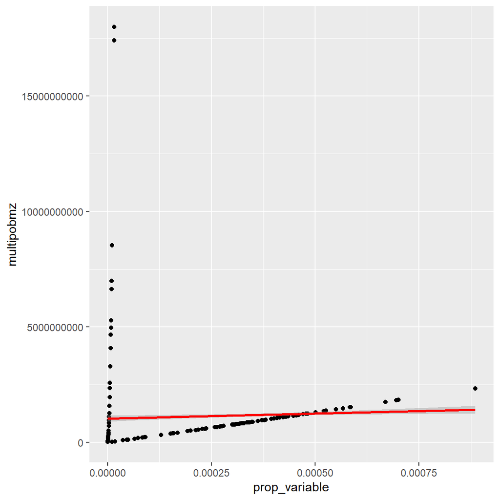

```r
ggplot(frec_total, aes(x = prop_variable , y = multipobmz)) +
  geom_point() +
  stat_smooth(method = "lm", col = "red")
```

### 6.4.1 Análisis de residuos

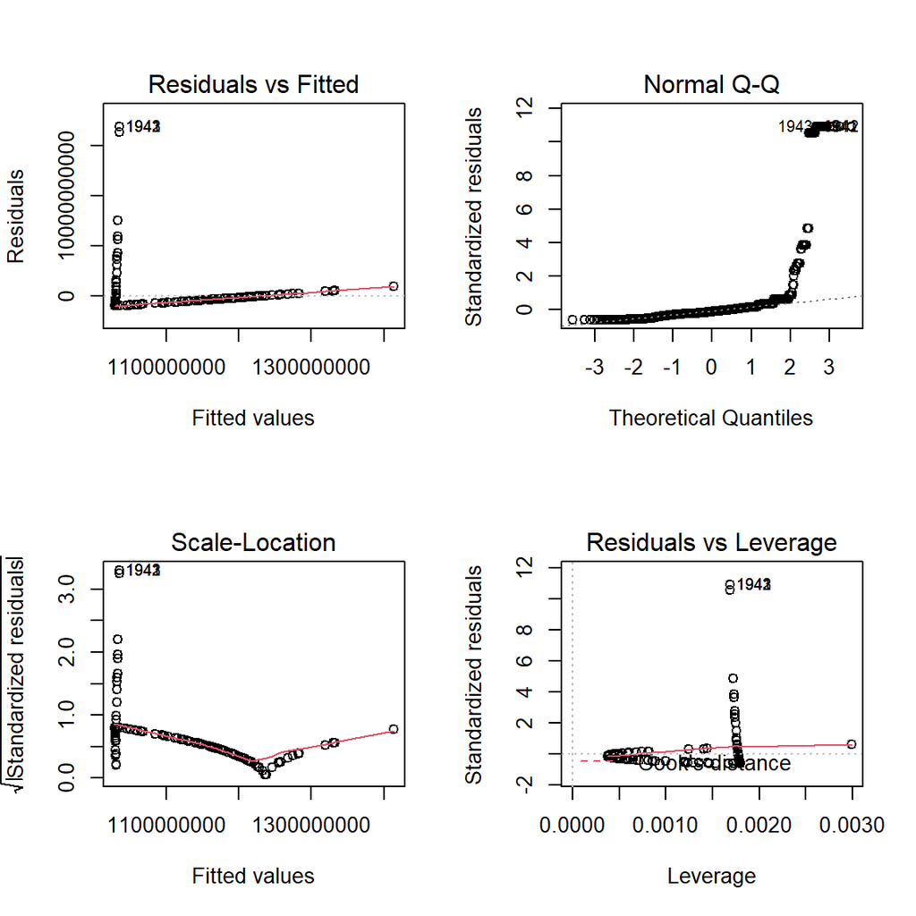

```r
par(mfrow = c (2,2))
plot(linearMod)
```

# 7 Modelos alternativos

```r
frecuencia <- frec_total$prop_variable
union <- frec_total
```

```r
### 8.1 Modelo cuadrático

linearMod <- lm( multipobmz~(frecuencia^2) , data=union)
datos <- summary(linearMod)
dato <- datos$adj.r.squared
modelo <- "cuadrático"
sintaxis <- "linearMod <- lm( multi_pob~(frecuencia^2) , data=h_y_m_comuna_corr_01)"

modelos1 <- cbind(modelo,dato,sintaxis)


modelos1 <- cbind(modelo,dato,sintaxis)

### 8.2 Modelo cúbico

linearMod <- lm( multipobmz~(frecuencia^3) , data=union)
datos <- summary(linearMod)
dato <- datos$adj.r.squared
modelo <- "cúbico"
sintaxis <- "linearMod <- lm( multi_pob~(frecuencia^3) , data=h_y_m_comuna_corr_01)"

modelos2 <- cbind(modelo,dato,sintaxis)

### 8.3 Modelo logarítmico

linearMod <- lm( multipobmz~log(frecuencia) , data=union)
datos <- summary(linearMod)
dato <- datos$adj.r.squared
modelo <- "logarítmico"
sintaxis <- "linearMod <- lm( multi_pob~log(frecuencia) , data=h_y_m_comuna_corr_01)"

modelos3 <- cbind(modelo,dato,sintaxis)

### 8.5 Modelo con raíz cuadrada

linearMod <- lm( multipobmz~sqrt(frecuencia) , data=union)
datos <- summary(linearMod)
dato <- datos$adj.r.squared
modelo <- "raíz cuadrada"
sintaxis <- "linearMod <- lm( multi_pob~sqrt(frecuencia) , data=h_y_m_comuna_corr_01)"

modelos5 <- cbind(modelo,dato,sintaxis)

### 8.6 Modelo raíz-raíz

linearMod <- lm( sqrt(multipobmz)~sqrt(frecuencia) , data=union)
datos <- summary(linearMod)
dato <- datos$adj.r.squared
modelo <- "raíz-raíz"
sintaxis <- "linearMod <- lm( sqrt(multi_pob)~sqrt(frecuencia) , data=h_y_m_comuna_corr_01)"

modelos6 <- cbind(modelo,dato,sintaxis)

### 8.7 Modelo log-raíz

linearMod <- lm( log(multipobmz)~sqrt(frecuencia) , data=union)
datos <- summary(linearMod)
dato <- datos$adj.r.squared
modelo <- "log-raíz"
sintaxis <- "linearMod <- lm( log(multi_pob)~sqrt(frecuencia) , data=h_y_m_comuna_corr_01)"

modelos7 <- cbind(modelo,dato,sintaxis)

### 8.8 Modelo raíz-log

linearMod <- lm( sqrt(multipobmz)~log(frecuencia) , data=union)
datos <- summary(linearMod)
dato <- datos$adj.r.squared
modelo <- "raíz-log"
sintaxis <- "linearMod <- lm( sqrt(multi_pob)~log(frecuencia) , data=h_y_m_comuna_corr_01)"

modelos8 <- cbind(modelo,dato,sintaxis)

### 8.9 Modelo log-log

linearMod <- lm( log(multipobmz)~log(frecuencia) , data=union)
datos <- summary(linearMod)
dato <- datos$adj.r.squared
modelo <- "log-log"
sintaxis <- "linearMod <- lm( log(multi_pob)~log(frecuencia) , data=h_y_m_comuna_corr_01)"

modelos9 <- cbind(modelo,dato,sintaxis)

modelos_bind <- rbind(modelos1, modelos2,modelos3,modelos5,modelos6,modelos7,modelos8,modelos9)
modelos_bind <- as.data.frame(modelos_bind)

modelos_bind <<- modelos_bind[order(modelos_bind$dato, decreasing = T ),]
h_y_m_comuna_corr_01 <<- union

kbl(modelos_bind) %>%
  kable_styling(bootstrap_options = c("striped", "hover")) %>%
  kable_paper() %>%
  scroll_box(width = "100%", height = "300px")
```

|  | modelo | dato | sintaxis |
| --- | --- | --- | --- |
| 6 | log-raíz | 0.321960410111249 | linearMod <- lm( log(multi_pob)~sqrt(frecuencia) , data=h_y_m_comuna_corr_01) |
| 8 | log-log | 0.252947896587329 | linearMod <- lm( log(multi_pob)~log(frecuencia) , data=h_y_m_comuna_corr_01) |
| 5 | raíz-raíz | 0.0687147844495207 | linearMod <- lm( sqrt(multi_pob)~sqrt(frecuencia) , data=h_y_m_comuna_corr_01) |
| 7 | raíz-log | 0.0267138362763014 | linearMod <- lm( sqrt(multi_pob)~log(frecuencia) , data=h_y_m_comuna_corr_01) |
| 3 | logarítmico | 0.00800326887225755 | linearMod <- lm( multi_pob~log(frecuencia) , data=h_y_m_comuna_corr_01) |
| 1 | cuadrático | 0.00251781025919018 | linearMod <- lm( multi_pob~(frecuencia^2) , data=h_y_m_comuna_corr_01) |
| 2 | cúbico | 0.00251781025919018 | linearMod <- lm( multi_pob~(frecuencia^3) , data=h_y_m_comuna_corr_01) |
| 4 | raíz cuadrada | 0.00128415458280939 | linearMod <- lm( multi_pob~sqrt(frecuencia) , data=h_y_m_comuna_corr_01) |